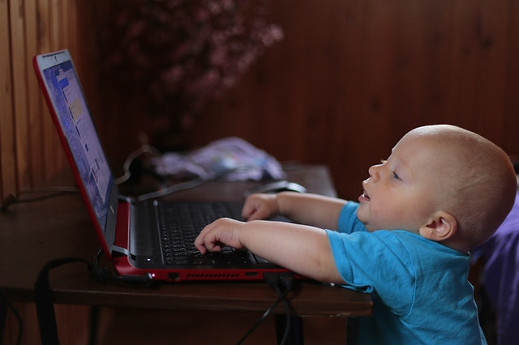

# HELP! My child **cannot** programm at the age of 5 - will it ever become a developer?

Before you panic - let's have a look at some famous developers / programmers of our time:  
**Bill Gates** programmed his first lines of code at the age of 13 - and created one of the widespreaded operating system most of the people have installed on their computers.  
**Larry Page** played with earliest computer stuff from his parents at the age of 6 - and programmed the most used search engine in the world "Google".  
**Mark Zuckerberg** started writing code in middle school - and developed one of the largest social network platform "Facebook" where people all over the world can connect and socialize.  
**Sir Timothy Berners Lee** built electronic devices to control his model trains at the age of a schoolboy - and developed not only the HTTP and HTML but also the Internet.

So **nobody** of them started at the age of 5...

### What about the other developers and programmers around the world?

Now have a look at the **"normal"**, the every-day developers and the **reality** beyond this famous personalities.  
The **data basis** will be the **Stack Overflow survey** from 2020. Stack Overflow is a global platform where developers - professionals and enthusiats - share their knowledge based on questions and answers to solve common or tricky coding problems.

Each year they do a survey beneath their users to examine aspects like **developer experience, career satisfaction, education level and used software or programming language.**  
In 2020 nearly **65,000 users** participated from around **180 countries** around the world.

Based on that data - what is the best age to start coding?

### Let's ask a few questions...

### Is 5 too early and 35 too late for the first lines of code to become a developer?

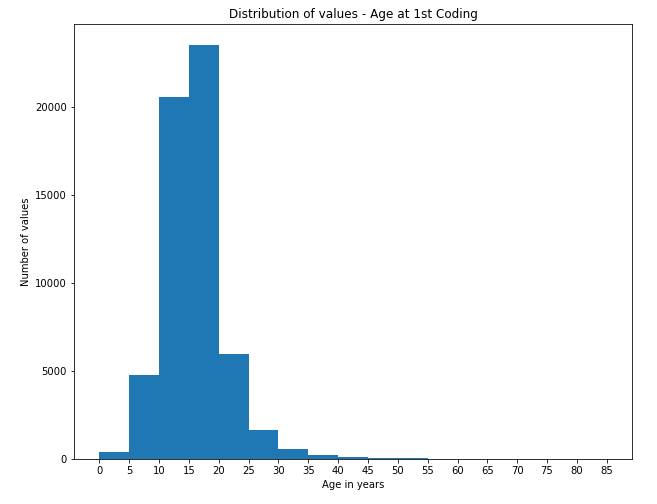

### Do my daughter should start earlier coding than my son?

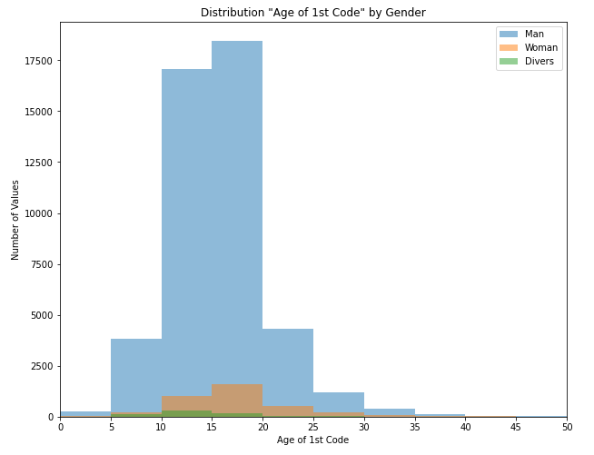

With regard to the starting age the **distribution by gender** is **similar** to the overall distribution. All gender groups **start mainly** between **10 and 20 years**. A little more people of the non-binary-gender-group start earlier by 10 to 15 years.

Besides that the diagram shows that the main people of the survey are men. In relation to that there are very little amount of women or transgender.

**Conclusion:**  
There is **no need** that your **daughter starts earlier** with programming code -  
but **if she likes tech, she should definitely do start** - we do need some support in this men dominating field!

### When should my child start programming to study in a IT relevant field?

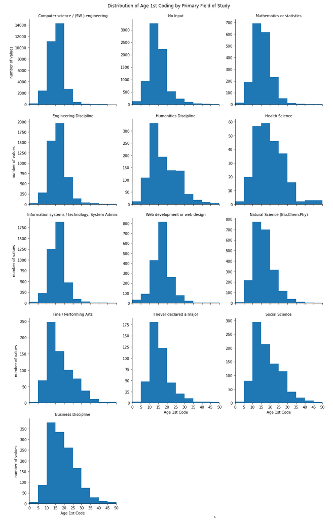

In comparison to that people with primary **IT-relevant studies** mainly **start** between **15 and 20** but there are a **lower number of people starting later**. The **majority starts** in the area between **10 and 20 years.**

**Conclusion:**  
If you would like that **your child studies "something with IT"** - there is **no need to rush** regarding the programming eduction. Starting coding at an **age of 15 to 20** is sufficient.

## Dear Parents - keep calm...

... if your child do not programm at the age of 5, it can still become a famous and successful programmer.

Let your 5-year-old child play with other toys and wait until middle school to start programming ... just like Bill Gates or Mark Zuckerberg did.

**References / Sources:**

- https://de.wikipedia.org/wiki/Bill_Gates
- https://www.wissen.de/bildwb/bill-gates-wie-kam-gates-zum-programmieren
- https://en.wikipedia.org/wiki/Mark_Zuckerberg
- https://achievement.org/achiever/sir-timothy-berners-lee/
- https://en.wikipedia.org/wiki/Larry_Page
- https://achievement.org/achiever/larry-page/#biography

**Licences:**

- Picture of blog post is taken from pexels and is licensed under the Creative Commons Zero (CC0) license (https://www.pexels.com/photo/boy-wearing-blue-t-shirt-using-black-laptop-computer-in-a-dim-lighted-scenario-159533/ | https://www.pexels.com/creative-commons-images/).